# Data-606-Lab 4 - The normal distribution

## Exercise 3

Make a normal probability plot of sim_norm. Do all of the points fall on the line? How does this plot compare to the probability plot for the real data? (Since sim_norm is not a data frame, it can be put directly into the sample argument and the data argument can be dropped.)

**Answer:**

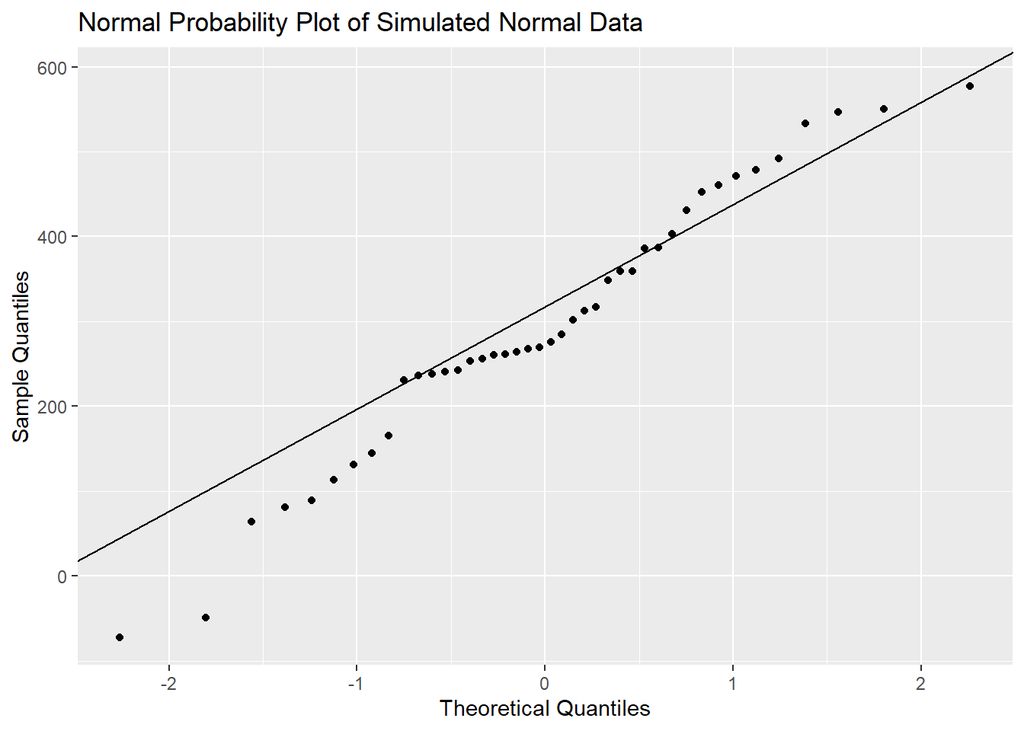

```r
#Normal probability plot of sim_norm
ggplot(data = NULL, aes(sample = sim_norm)) +
  geom_qq() +
  geom_qq_line() +
  labs(
    title = "Normal Probability Plot of Simulated Normal Data",
    x = "Theoretical Quantiles",
    y = "Sample Quantiles"
  )
```

Even better than comparing the original plot to a single plot generated from a normal distribution is to compare it to many more plots using the following function. It shows the Q-Q plot corresponding to the original data in the top left corner, and the Q-Q plots of 8 different simulated normal data. It may be helpful to click the zoom button in the plot window.

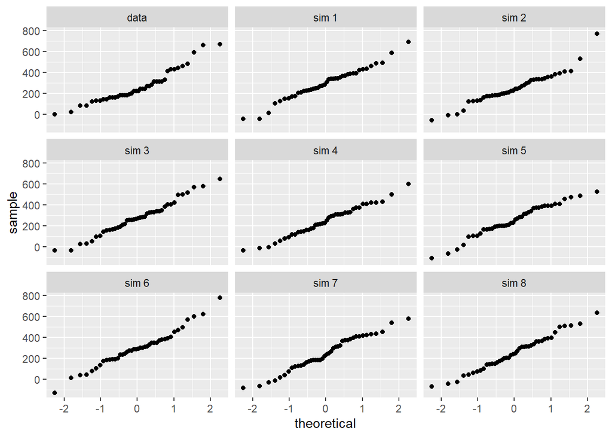

```r
qqnormsim(sample = cal_fat, data = dairy_queen)
```

## Exercise 4

Does the normal probability plot for the calories from fat look similar to the plots created for the simulated data? That is, do the plots provide evidence that the calories are nearly normal?

**Answer:**

Yes, the normal probability plot for the calories from fat looks similar to some of the simulated normal plots, particularly sim6, sim7, and sim8. This provides evidence that the calories from fat are approximately normally distributed, although there are some deviations from the line.

## Exercise 5

Using the same technique, determine whether or not the calories from McDonald’s menu appear to come from a normal distribution.

**Answer:**

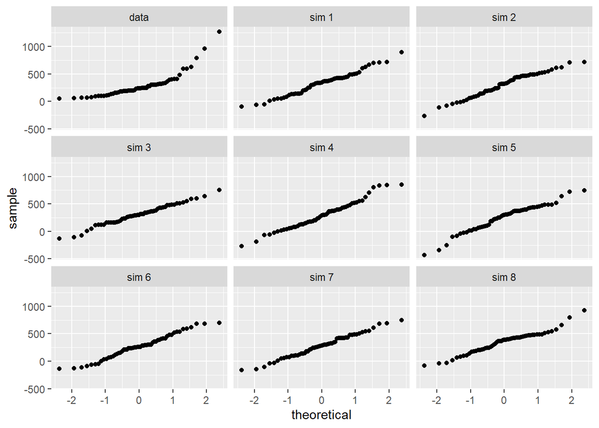

```r
mdmean <- mean(mcdonalds$cal_fat)
mdsd   <- sd(mcdonalds$cal_fat)

set.seed(59)
sim_norm <- rnorm(n = nrow(mcdonalds), mean = mdmean, sd = mdsd)

qqnormsim(sample = cal_fat, data = mcdonalds)
```

Normal probabilities

Okay, so now you have a slew of tools to judge whether or not a variable is normally distributed. Why should you care?

It turns out that statisticians know a lot about the normal distribution. Once you decide that a random variable is approximately normal, you can answer all sorts of questions about that variable related to probability. Take, for example, the question of, “What is the probability that a randomly chosen Dairy Queen product has more than 600 calories from fat?”

If we assume that the calories from fat from Dairy Queen’s menu are normally distributed (a very close approximation is also okay), we can find this probability by calculating a Z score and consulting a Z table (also called a normal probability table). In R, this is done in one step with the function pnorm().

```r
1 - pnorm(q = 600, mean = dqmean, sd = dqsd)
```

```
## [1] 0.01501523
```

Note that the function pnorm() gives the area under the normal curve below a given value, q, with a given mean and standard deviation. Since we’re interested in the probability that a Dairy Queen item has more than 600 calories from fat, we have to take one minus that probability.

Assuming a normal distribution has allowed us to calculate a theoretical probability. If we want to calculate the probability empirically, we simply need to determine how many observations fall above 600 then divide this number by the total sample size.

```r
dairy_queen %>%
  filter(cal_fat > 600) %>%
  summarise(percent = n() / nrow(dairy_queen))
```

```
## # A tibble: 1 × 1
##   percent
##     <dbl>
## 1  0.0476
```

Although the probabilities are not exactly the same, they are reasonably close. The closer that your distribution is to being normal, the more accurate the theoretical probabilities will be.

## Exercise 6

Write out two probability questions that you would like to answer about any of the restaurants in this dataset. Calculate those probabilities using both the theoretical normal distribution as well as the empirical distribution (four probabilities in all). Which one had a closer agreement between the two methods?

**Answer:**

Question 1: What is the probability that a randomly selected Arby’s menu item has more than 50 grams of total carbohydrates?

Question 2: What is the probability that a randomly selected Arby’s menu item has less than 1500 mg of sodium?

For Question 1, the theoretical probability was calculated using the normal distribution, and the empirical probability was calculated from the actual Arby’s data.

For Question 2, I used the same approach, calculating the theoretical probability using the normal distribution and the empirical probability from the observed data.

The theoretical and empirical probabilities were reasonably close, although they were not exactly the same. The question with the smaller difference between the theoretical and empirical probabilities had the closer agreement.

```r
## Exercise 6
## Probability questions for Arby's menu items

# Load packages
library(tidyverse)
library(openintro)

# Load the fastfood data
data("fastfood", package = "openintro")

# Filter for Arby's
Arbys <- fastfood %>%
  filter(restaurant == "Arbys")

# View the data
Arbys
```

```
## # A tibble: 55 × 17
##    restaurant item      calories cal_fat total_fat sat_fat trans_fat cholesterol
##    <chr>      <chr>        <dbl>   <dbl>     <dbl>   <dbl>     <dbl>       <dbl>
##  1 Arbys      Arby's M…      330     100        11     4         0            30
##  2 Arbys      Arby-Q S…      400      90        10     3         0            30
##  3 Arbys      Beef 'n …      450     180        20     6         1            50
##  4 Arbys      Beef 'n …      630     290        32    11         1.5         100
##  5 Arbys      Bourbon …      650     300        33    12         1           105
##  6 Arbys      Bourbon …      690     280        31     9         0            90
##  7 Arbys      Bourbon …      690     280        31     9         0            90
##  8 Arbys      Buttermi…      540     220        24     4.5       0            60
##  9 Arbys      Buttermi…      650     280        31     9         0            90
## 10 Arbys      Buttermi…      690     310        35    10         0           110
## # ℹ 45 more rows
## # ℹ 9 more variables: sodium <dbl>, total_carb <dbl>, fiber <dbl>, sugar <dbl>,
## #   protein <dbl>, vit_a <dbl>, vit_c <dbl>, calcium <dbl>, salad <chr>
```

```r
# ---------------------------------------------------------
# Question 1:
# What is the probability that an Arby's menu item
# has more than 50 grams of total carbohydrates?
# ---------------------------------------------------------

# Calculate mean and standard deviation
abcarbsmean <- mean(Arbys$total_carb, na.rm = TRUE)
abcarbssd <- sd(Arbys$total_carb, na.rm = TRUE)

abcarbsmean
```

```
## [1] 44.87273
```

```r
abcarbssd
```

```
## [1] 19.0963
```

```r
# Theoretical probability using normal distribution
# P(total_carb > 50)

total_carbs_theoretical <- 1 - pnorm(
  q = 50,
  mean = abcarbsmean,
  sd = abcarbssd
)

total_carbs_theoretical
```

```
## [1] 0.3941589
```

```r
# Empirical probability from the actual data
total_carbs_empirical <- Arbys %>%
  summarise(
    probability = mean(total_carb > 50, na.rm = TRUE)
  )

total_carbs_empirical
```

```
## # A tibble: 1 × 1
##   probability
##         <dbl>
## 1       0.364
```

```r
# Convert empirical probability to percentage
total_carbs_empirical * 100
```

```
##   probability
## 1    36.36364
```

```r
# ---------------------------------------------------------
# Question 2:
# What is the probability that an Arby's menu item
# has less than 1500 mg of sodium?
# ---------------------------------------------------------

# Calculate mean and standard deviation
abNAmean <- mean(Arbys$sodium, na.rm = TRUE)
abNAsd <- sd(Arbys$sodium, na.rm = TRUE)

abNAmean
```

```
## [1] 1515.273
```

```r
abNAsd
```

```
## [1] 663.6651
```

```r
# Theoretical probability using normal distribution
# P(sodium < 1500)

sodium_theoretical <- pnorm(
  q = 1500,
  mean = abNAmean,
  sd = abNAsd
)

sodium_theoretical
```

```
## [1] 0.4908201
```

```r
# Empirical probability from the actual data
sodium_empirical <- Arbys %>%
  summarise(
    probability = mean(sodium < 1500, na.rm = TRUE)
  )

sodium_empirical
```

```
## # A tibble: 1 × 1
##   probability
##         <dbl>
## 1       0.509
```

```r
# Convert empirical probability to percentage
sodium_empirical * 100
```

```
##   probability
## 1    50.90909
```

```r
# ---------------------------------------------------------
# Compare theoretical and empirical probabilities
# ---------------------------------------------------------

# Extract the empirical values
carb_empirical <- total_carbs_empirical$probability
sodium_empirical_value <- sodium_empirical$probability

# Calculate differences
carb_difference <- abs(
  total_carbs_theoretical - carb_empirical
)

sodium_difference <- abs(
  sodium_theoretical - sodium_empirical_value
)

carb_difference
```

```
## [1] 0.03052256
```

```r
sodium_difference
```

```
## [1] 0.01827084
```

```r
# Determine which question had closer agreement
if (carb_difference < sodium_difference) {
  print("The total carbohydrates question had closer agreement.")
} else if (sodium_difference < carb_difference) {
  print("The sodium question had closer agreement.")
} else {
  print("Both questions had the same agreement.")
}
```

```
## [1] "The sodium question had closer agreement."
```

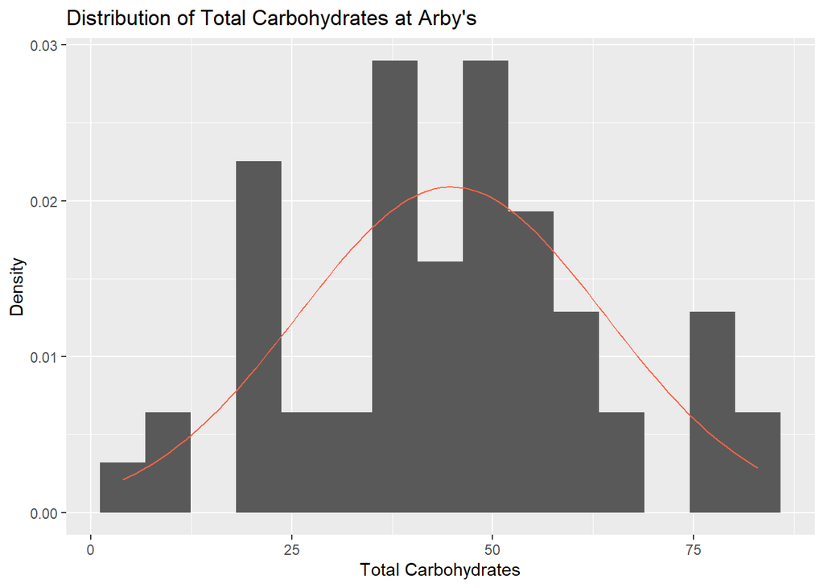

```r
# ---------------------------------------------------------
# Density histogram for total carbohydrates
# ---------------------------------------------------------

ggplot(data = Arbys, aes(x = total_carb)) +
  geom_histogram(aes(y = after_stat(density)), bins = 15) +
  stat_function(
    fun = dnorm,
    args = c(mean = abcarbsmean, sd = abcarbssd),
    color = "tomato"
  ) +
  labs(
    title = "Distribution of Total Carbohydrates at Arby's",
    x = "Total Carbohydrates",
    y = "Density"
  )
```

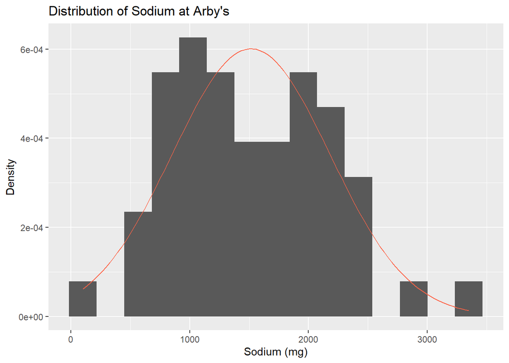

```r
# ---------------------------------------------------------
# Density histogram for sodium
# ---------------------------------------------------------

ggplot(data = Arbys, aes(x = sodium)) +
  geom_histogram(aes(y = after_stat(density)), bins = 15) +
  stat_function(
    fun = dnorm,
    args = c(mean = abNAmean, sd = abNAsd),
    color = "tomato"
  ) +
  labs(
    title = "Distribution of Sodium at Arby's",
    x = "Sodium (mg)",
    y = "Density"
  )
```

## Exercise 7

Now let’s consider some of the other variables in the dataset. Out of all the different restaurants, which ones’ distribution is the closest to normal for sodium?

**Answer:**

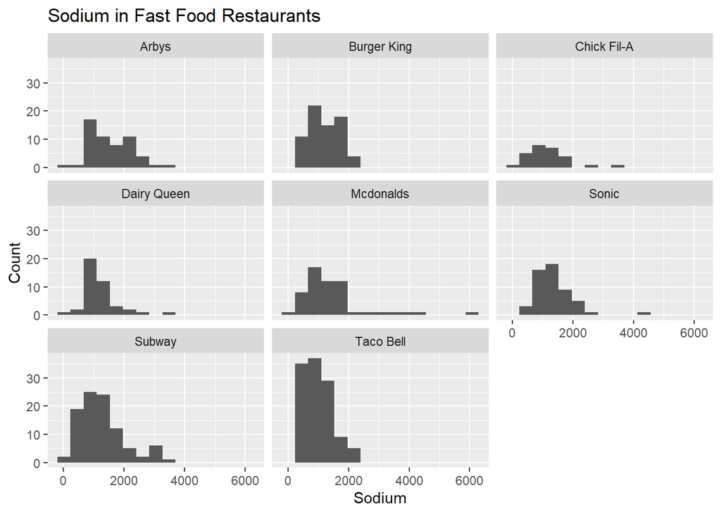

```r
#Histograms Sodium in all Restaurants
fastfood %>%
  group_by(restaurant) %>%
  ggplot() +
  geom_histogram(aes(x = sodium), bins = 15) +
  ggtitle("Sodium in Fast Food Restaurants") +
  xlab("Sodium") +
  ylab("Count") +
  facet_wrap(. ~restaurant)
```

Among the restaurants, Burger King appears to have a sodium distribution that is closest to normal. Its distribution is relatively symmetric and bell-shaped compared with the other restaurants.

## Exercise 8

Note that some of the normal probability plots for sodium distributions seem to have a stepwise pattern. why do you think this might be the case?

**Answer:**

The stepwise pattern may occur because many menu items have the same or rounded sodium values. These repeated values create ties in the data, which can make the normal probability plot appear stepwise.

## Exercise 9

As you can see, normal probability plots can be used both to assess normality and visualize skewness. Make a normal probability plot for the total carbohydrates from a restaurant of your choice. Based on this normal probability plot, is this variable left skewed, symmetric, or right skewed? Use a histogram to confirm your findings.

**Answer:**

```r
#filter for Subway's restaurant
Subway <- fastfood %>%
  filter(restaurant == "Subway")
Subway
```

```
## # A tibble: 96 × 17
##    restaurant item      calories cal_fat total_fat sat_fat trans_fat cholesterol
##    <chr>      <chr>        <dbl>   <dbl>     <dbl>   <dbl>     <dbl>       <dbl>
##  1 Subway     "6\" B.L…      320      80         9     4           0          20
##  2 Subway     "Footlon…      640     160        18     8           0          40
##  3 Subway     "6\" BBQ…      430     160        18     6           0          50
##  4 Subway     "Footlon…      860     320        36    12           0         100
##  5 Subway     "6\" Big…      580     310        31    11           0          85
##  6 Subway     "Footlon…     1160     620        62    22           0         170
##  7 Subway     "6\" Big…      500     150        17     9           1          85
##  8 Subway     "Footlon…     1000     300        34    18           2         170
##  9 Subway     "Kids Mi…      180      20         3     0.5         0          10
## 10 Subway     "6\" Bla…      290      40         5     1           0          20
## # ℹ 86 more rows
## # ℹ 9 more variables: sodium <dbl>, total_carb <dbl>, fiber <dbl>, sugar <dbl>,
## #   protein <dbl>, vit_a <dbl>, vit_c <dbl>, calcium <dbl>, salad <chr>
```

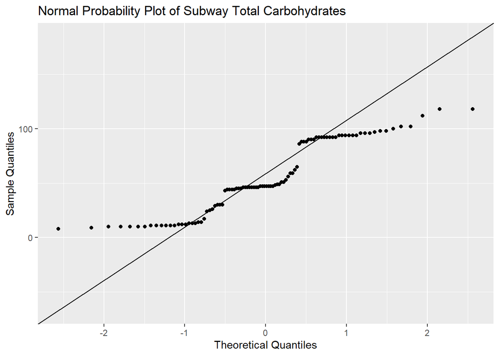

```r
#Probability Plot
Subway_pp <- ggplot(data = Subway, aes(sample = total_carb)) +
  geom_qq() +
  geom_qq_line() +
  labs(
    title = "Normal Probability Plot of Subway Total Carbohydrates",
    x = "Theoretical Quantiles",
    y = "Sample Quantiles"
  )

Subway_pp
```

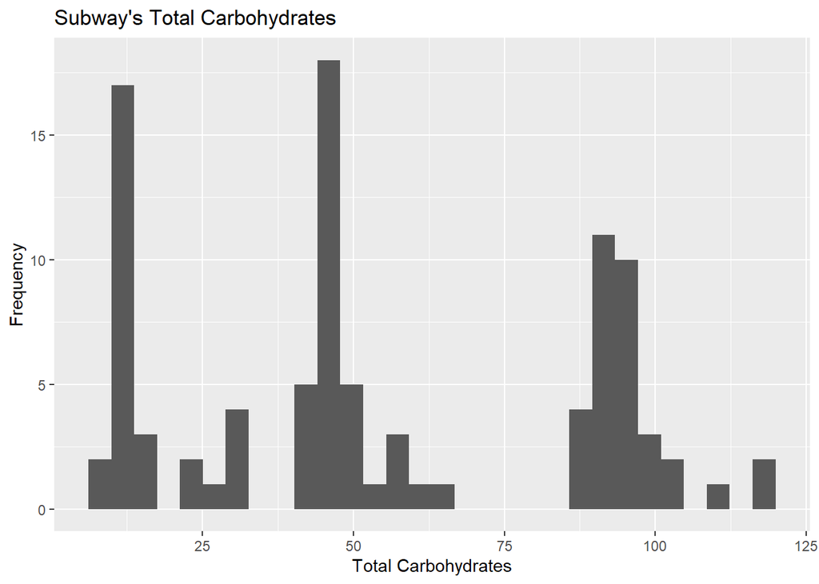

```r
#Subway's histogram
Subway <- ggplot(Subway, aes(x=total_carb)) +
  geom_histogram()  +
  xlab("Total Carbohydrates") +
  ylab("Frequency") +
  ggtitle("Subway's Total Carbohydrates")

Subway
```

```r
Subway <- fastfood %>%
  filter(restaurant == "Subway")
Subway
```

```
## # A tibble: 96 × 17
##    restaurant item      calories cal_fat total_fat sat_fat trans_fat cholesterol
##    <chr>      <chr>        <dbl>   <dbl>     <dbl>   <dbl>     <dbl>       <dbl>
##  1 Subway     "6\" B.L…      320      80         9     4           0          20
##  2 Subway     "Footlon…      640     160        18     8           0          40
##  3 Subway     "6\" BBQ…      430     160        18     6           0          50
##  4 Subway     "Footlon…      860     320        36    12           0         100
##  5 Subway     "6\" Big…      580     310        31    11           0          85
##  6 Subway     "Footlon…     1160     620        62    22           0         170
##  7 Subway     "6\" Big…      500     150        17     9           1          85
##  8 Subway     "Footlon…     1000     300        34    18           2         170
##  9 Subway     "Kids Mi…      180      20         3     0.5         0          10
## 10 Subway     "6\" Bla…      290      40         5     1           0          20
## # ℹ 86 more rows
## # ℹ 9 more variables: sodium <dbl>, total_carb <dbl>, fiber <dbl>, sugar <dbl>,
## #   protein <dbl>, vit_a <dbl>, vit_c <dbl>, calcium <dbl>, salad <chr>
```

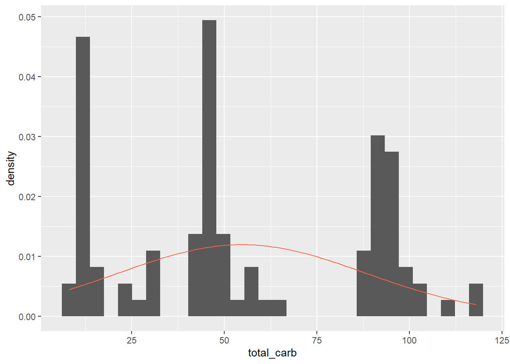

```r
#Mean and standard deviation for Subway
s_mean <- mean(Subway$total_carb)
s_sd   <- sd(Subway$total_carb)

#Density Histogram
ggplot(data = Subway, aes(x = total_carb)) +
        geom_blank() +
        geom_histogram(aes(y = ..density..)) +
        stat_function(fun = dnorm, args = c(mean = s_mean, sd = s_sd), col = "tomato")
```